# 00 - Verified genetic parameters for the NUE breeding simulation

Holstein / Red Dairy Cattle / Jersey x Denmark / Sweden / Finland / Germany

Prepared by Emmanuel Ismaila for QGG, Aarhus University

2026-11-08

# 1 Purpose and rules

This file is the **single source of truth** for every genetic parameter used downstream (`01_founders_burnin.Rmd` onwards). Rules applied:

1. A value enters the simulation only if it was read from the cited source (status `VERIFIED`).
2. Values from outside the Nordic countries are allowed only from neighbouring European populations, and are labelled `VERIFIED-EU` (or `VERIFIED-NON-EU` if no European estimate was found).
3. Where a source reports a **range**, the midpoint is used and the range is kept so it can be swept in sensitivity analysis. The midpoint is a modelling choice, not a published value.
4. Anything not yet read from a primary source is `PENDING` and is **not** used until resolved.

# 2 Population sizes

**Basis (revised 7 Nov 2026, by my decision):** the CFIT installation numbers reported by Lassen & Borchersen, *Cattle FeedInTake* (presentation “3.2 CFIT Cattle 3D cameras”, installations as of May 2026): **28,400 cows** - 8,100 Red Dairy Cattle (12 farms), 8,300 Jersey (11 farms) and 12,000 Holstein (16 farms) - in 4 countries. Known allocations from the same slide: 2 RDC farms with 500 cows in Finland, 2 RDC farms with 500 cows in Sweden, 2 Holstein farms with 750 cows in Germany (country assignment of these three groups as I specified). The breed labels of the three rows (8,100 / 8,300 / 12,000) are my mapping; the slide shows the numbers without breed names. This replaces the ICAR 2026 abstract (25,614 cows; Lassen, Thomasen & Borchersen).

```r
totals <- data.table(breed = c("RDC", "JER", "HOL"), n_cows = c(8100, 8300, 12000), n_farms = c(12, 11, 16))
n_breed <- setNames(totals$n_cows, totals$breed)[c("HOL", "RDC", "JER")]
N_total <- sum(n_breed)
stopifnot(N_total == 28400)
totals[, proportion := round(n_cows / N_total, 4)][]
```

```
##    breed n_cows n_farms proportion
## 1:   RDC   8100      12     0.2852
## 2:   JER   8300      11     0.2923
## 3:   HOL  12000      16     0.4225
```

**Allocation to countries (my rule, 7 Nov 2026).** Within each breed, the cows and farms not covered by the known allocations are split **equally** over the four countries, and the known cows/farms are added to their country. Germany is coded `DEU` (ISO 3166), the code used by every file of the pipeline; it is my `GER`.

```r
countries <- c("DNK", "SWE", "FIN", "DEU")
nC <- length(countries)
known <- data.table(country = c("FIN", "SWE", "DEU"), breed = c("RDC", "RDC", "HOL"),
                    cows = c(500, 500, 750), farms = c(2, 2, 2))
alloc <- rbindlist(lapply(totals$breed, function(b) {
  k <- known[breed == b]
  rem_c <- totals[breed == b, n_cows] - sum(k$cows); rem_f <- totals[breed == b, n_farms] - sum(k$farms)
  d <- data.table(breed = b, country = countries, cows_exact = rem_c / nC, farms_exact = rem_f / nC)
  d[k, on = "country", `:=`(cows_exact = cows_exact + i.cows, farms_exact = farms_exact + i.farms)]
  d
}))
kable(dcast(alloc, country ~ breed, value.var = "cows_exact"), caption = "Cows, exact allocation (my formula)")
```

Cows, exact allocation (my formula)

| country | HOL | JER | RDC |
| --- | --- | --- | --- |
| DEU | 3562.5 | 2075 | 1775 |
| DNK | 2812.5 | 2075 | 1775 |
| FIN | 2812.5 | 2075 | 2275 |
| SWE | 2812.5 | 2075 | 2275 |

```r
kable(dcast(alloc, country ~ breed, value.var = "farms_exact"), digits = 2, caption = "Farms, exact allocation (my formula)")
```

Farms, exact allocation (my formula)

| country | HOL | JER | RDC |
| --- | --- | --- | --- |
| DEU | 5.5 | 2.75 | 2 |
| DNK | 3.5 | 2.75 | 2 |
| FIN | 3.5 | 2.75 | 4 |
| SWE | 3.5 | 2.75 | 4 |

**Rounding.** Both use the largest-remainder (Hamilton) method: floor every cell, then give the units still missing to the cells with the largest fractional parts; ties are broken by country order DNK, SWE, FIN, DEU.

- **Cows:** within each breed, so breed totals stay 8,100 / 8,300 / 12,000. Only Holstein has fractions (x.5 in every country), so DNK and SWE round up and FIN and DEU round down.
- **Farms:** the reported 39 farms (12 + 11 + 16) are scaled to **40**, inside the reported range of 39 farms (breed rows) to 42 herds (“42 herds in 4 countries”, same slide), by multiplying every cell by 40/39 and apportioning 40 farms over all 12 breed x country cells.

```r
lr_round <- function(x, total, order_key) {     # largest remainder; ties by order_key
  f <- floor(x); left <- total - sum(f)
  o <- order(-(x - f), order_key)
  if (left > 0) f[o[seq_len(left)]] <- f[o[seq_len(left)]] + 1
  f
}
ckey <- match(alloc$country, countries)
alloc[, n := lr_round(cows_exact, sum(cows_exact), ckey[.I]), by = breed]
n_herds_total <- 40
alloc[, farms := lr_round(farms_exact * n_herds_total / sum(farms_exact), n_herds_total, ckey)]
split <- alloc[, .(breed, country, n, farms)]
kable(dcast(split, country ~ breed, value.var = "n")[, total := HOL + JER + RDC][], caption = "Cows per country and breed (simulated)")
```

Cows per country and breed (simulated)

| country | HOL | JER | RDC | total |
| --- | --- | --- | --- | --- |
| DEU | 3562 | 2075 | 1775 | 7412 |
| DNK | 2813 | 2075 | 1775 | 6663 |
| FIN | 2812 | 2075 | 2275 | 7162 |
| SWE | 2813 | 2075 | 2275 | 7163 |

```r
kable(dcast(split, country ~ breed, value.var = "farms")[, total := HOL + JER + RDC][], caption = "Herds per country and breed (simulated)")
```

Herds per country and breed (simulated)

| country | HOL | JER | RDC | total |
| --- | --- | --- | --- | --- |
| DEU | 6 | 3 | 2 | 11 |
| DNK | 4 | 3 | 2 | 9 |
| FIN | 3 | 3 | 4 | 10 |
| SWE | 3 | 3 | 4 | 10 |

```r
stopifnot(sum(split$n) == N_total, sum(split$farms) == n_herds_total,
          all(split[, sum(n), by = breed][order(breed)]$V1 == totals[order(breed)]$n_cows))
split[, .(farms = sum(farms)), by = breed]
```

```
##    breed farms
## 1:   RDC    12
## 2:   JER    12
## 3:   HOL    16
```

The farm rounding changes the breed totals from 12 / 11 / 16 (RDC / Jersey / Holstein) to the values in the last table; scaling to 40 farms is a design choice; the split follows mechanically from the rule.

## 2.1 Herds (blocks)

**Herds are single-breed**, as the CFIT farm counts are per breed. Each breed x country cell gets the number of herds above, and its cows are spread evenly over them. This replaces the earlier 32 mixed-breed herds (8 per country). Consequence for files 02-04: herd is nested in breed, so the herd x generation fixed effects absorb the breed effect; within-breed ranking is unaffected.

```r
farms <- split[farms > 0, .(herd = sprintf("%s_%s_H%02d", country, breed, seq_len(farms)), n_cows_herd = n / farms),
               by = .(breed, country)]
kable(farms[, .(herds = .N, mean_cows_per_herd = round(mean(n_cows_herd))), by = .(breed, country)],
      caption = "Herds and mean herd size per breed x country")
```

Herds and mean herd size per breed x country

| breed | country | herds | mean_cows_per_herd |
| --- | --- | --- | --- |
| RDC | DNK | 2 | 888 |
| RDC | SWE | 4 | 569 |
| RDC | FIN | 4 | 569 |
| RDC | DEU | 2 | 888 |
| JER | DNK | 3 | 692 |
| JER | SWE | 3 | 692 |
| JER | FIN | 3 | 692 |
| JER | DEU | 3 | 692 |
| HOL | DNK | 4 | 703 |
| HOL | SWE | 3 | 938 |
| HOL | FIN | 3 | 937 |
| HOL | DEU | 6 | 594 |

```r
stopifnot(nrow(farms) == n_herds_total)
```

## 2.2 Germany and the NAV evaluation

The NAV documentation (May 2024) describes a **joint Denmark-Sweden-Finland** evaluation. Germany is not part of it, so NAV’s “common genetic parameters for all countries” assumption does not cover German herds. That makes the GxE sensitivity scenario (below) more relevant for DEU than for the three NAV countries.

# 3 Heritabilities

```r
h2 <- fread(text = "
trait|code|HOL|RDC|JER|range_low|range_high|status|population|source
305-d milk yield, 1st lactation|MY|0.43|0.39|0.44|NA|NA|VERIFIED|NAV joint DK-SE-FI evaluation|NAV routine genetic evaluation, May 2024, Tables 4.1-4.3
305-d protein yield, 1st lactation (substitute for protein %)|PY|0.35|0.33|0.38|NA|NA|VERIFIED|NAV joint DK-SE-FI evaluation|NAV routine genetic evaluation, May 2024, Tables 4.1-4.3
Saved Feed (feed efficiency; NAV index = 0.40 ECM + 4.0 dBW - DMI)|SF|0.23|0.23|0.23|0.17|0.29|PROXY-NORDIC (ReFI, a feed-saved metric; Nordic Red only; +-1 SE as range)|Finnish Nordic Red, 654 primiparous cows|Lidauer et al. 2023, Animal 17:100917, Table 2 (ReFI h2 0.23, SE 0.06)
Somatic cell count, test-day|SCS|0.095|0.115|0.095|0.06|0.14|VERIFIED (midpoint)|Nordic HOL/RDC (SE) and JER (DK)|Vargas Jurado et al. 2026, J Dairy Sci 109:6387-6400; NAV May 2024 Sec. 8 (0.08-0.15)
Resilience: log-variance of daily milk deviations|LNVAR|0.22|0.22|0.22|0.20|0.24|VERIFIED-EU (midpoint)|Dutch AMS herds, 198,754 1st-parity cows|Poppe, Mulder & Veerkamp, ADSA 2019 abstract #286
Interval calving-first insemination, 1st lact.|ICF|0.05|0.04|0.04|NA|NA|VERIFIED|NAV joint DK-SE-FI evaluation|NAV routine genetic evaluation, May 2024, Table 6.x
Longevity (NAV longevity model)|LONG|0.056|0.056|0.056|0.022|0.090|VERIFIED (midpoint, via review)|Danish dairy cattle|Clasen et al. 2017 as tabulated in Hu et al. 2021, Front Genet 12:695543
Milk urea (test-day MU, mmol/L)|MUN|0.22|0.24|0.18|NA|NA|VERIFIED|Danish Holstein 323,800 / Jersey 70,634 / Red 27,870 cows, routine recording 2019-2020|Buitenhuis & Poulsen 2023, J Dairy Sci 106:5562-5569, Table 2 (SE 0.004 / 0.01 / 0.01)
Predicted nitrogen use efficiency|NUE|0.13|0.13|0.13|0.12|0.14|VERIFIED-EU (midpoint)|Holstein, 154 farms in 5 European countries|Chen et al. 2021, J Dairy Sci 104:4413-4423
Enteric methane concentration in breath (CH4_C, daily, sniffer)|CH4|0.175|0.175|0.175|0.16|0.19|VERIFIED-DK, Holstein only (midpoint of parity groups)|Danish Holstein, 4,019 cows, 9 commercial farms, 587,640 daily records|Schneider et al. 2025, J Dairy Sci 108:12519-12530, Table 2 (PP 0.19 SE 0.03; MLP 0.16 SE 0.02)
305-d fat yield, 1st lactation (completes the NTM Yield sub-index; added 7 Nov 2026)|FY|0.36|0.34|0.35|NA|NA|VERIFIED|NAV joint DK-SE-FI evaluation|NAV routine genetic evaluation, May 2024, Tables 4.1-4.3
Udder conformation (represented by udder depth, 1st lactation; highest correlation with the NAV udder index: 0.86 / 0.72 / 0.87)|UDC|0.39|0.34|0.34|NA|NA|VERIFIED (representative component)|NAV joint evaluation|NAV routine genetic evaluation, May 2024, Tables 11.3-11.5 and 11.10
Birth index (represented by direct stillbirth, 1st calving; correlation with the birth index 0.96 / 0.95 / 0.95)|BI|0.040|0.058|0.034|NA|NA|VERIFIED (representative component)|NAV joint evaluation|NAV routine genetic evaluation, May 2024, Tables 7.4 and 7.10
Calving index (represented by maternal stillbirth, 1st calving; correlation with the calving index 0.96 / 0.93 / 0.90)|CI|0.036|0.038|0.023|NA|NA|VERIFIED (representative component)|NAV joint evaluation|NAV routine genetic evaluation, May 2024, Tables 7.3 and 7.9
General health (represented by other metabolic diseases, 1st lactation; highest correlation with the general health index 0.83 / 0.81 / 0.88)|GH|0.006|0.003|0.004|NA|NA|VERIFIED (representative component)|NAV joint evaluation|NAV routine genetic evaluation, May 2024, Tables 9.3-9.5; NAV routine evaluation 2020, Table 41
Claw health (represented by sole ulcer, 1st lactation; correlation with the claw index 0.80 / 0.83 / 0.90)|CLAW|0.036|0.020|0.019|NA|NA|VERIFIED (representative component)|NAV joint evaluation|NAV routine genetic evaluation, May 2024, Tables 10.2-10.4 and 10.13
Youngstock survival (represented by component HP2 in NAV notation, the component with the highest correlation with the index, 0.89-0.98)|YS|0.011|0.023|0.012|NA|NA|VERIFIED (representative component)|NAV joint evaluation|NAV routine genetic evaluation, May 2024, Tables 13.1-13.3 and 13.5
")
# Dropped on 7 Nov 2026 (my decisions, 21:50 and 21:54): birth index, calving index, general health, youngstock
# survival, claw health and udder conformation, because most of their correlations with the other traits are unpublished. Their heritability rows
# are kept above for the record, but they are not simulated, and every correlation pair with them is removed.
dropped <- c("BI", "CI", "GH", "YS", "CLAW", "UDC")   # CLAW and UDC dropped at 21:54, same reason
h2_dropped <- h2[code %in% dropped]; h2 <- h2[!code %in% dropped]
kable(h2, caption = "Heritabilities used in the simulation (breed-specific where published)")
```

Heritabilities used in the simulation (breed-specific where published)

| trait | code | HOL | RDC | JER | range_low | range_high | status | population | source |
| --- | --- | --- | --- | --- | --- | --- | --- | --- | --- |
| 305-d milk yield, 1st lactation | MY | 0.430 | 0.390 | 0.440 | NA | NA | VERIFIED | NAV joint DK-SE-FI evaluation | NAV routine genetic evaluation, May 2024, Tables 4.1-4.3 |
| 305-d protein yield, 1st lactation (substitute for protein %) | PY | 0.350 | 0.330 | 0.380 | NA | NA | VERIFIED | NAV joint DK-SE-FI evaluation | NAV routine genetic evaluation, May 2024, Tables 4.1-4.3 |
| Saved Feed (feed efficiency; NAV index = 0.40 ECM + 4.0 dBW - DMI) | SF | 0.230 | 0.230 | 0.230 | 0.170 | 0.29 | PROXY-NORDIC (ReFI, a feed-saved metric; Nordic Red only; +-1 SE as range) | Finnish Nordic Red, 654 primiparous cows | Lidauer et al. 2023, Animal 17:100917, Table 2 (ReFI h2 0.23, SE 0.06) |
| Somatic cell count, test-day | SCS | 0.095 | 0.115 | 0.095 | 0.060 | 0.14 | VERIFIED (midpoint) | Nordic HOL/RDC (SE) and JER (DK) | Vargas Jurado et al. 2026, J Dairy Sci 109:6387-6400; NAV May 2024 Sec. 8 (0.08-0.15) |
| Resilience: log-variance of daily milk deviations | LNVAR | 0.220 | 0.220 | 0.220 | 0.200 | 0.24 | VERIFIED-EU (midpoint) | Dutch AMS herds, 198,754 1st-parity cows | Poppe, Mulder & Veerkamp, ADSA 2019 abstract #286 |
| Interval calving-first insemination, 1st lact. | ICF | 0.050 | 0.040 | 0.040 | NA | NA | VERIFIED | NAV joint DK-SE-FI evaluation | NAV routine genetic evaluation, May 2024, Table 6.x |
| Longevity (NAV longevity model) | LONG | 0.056 | 0.056 | 0.056 | 0.022 | 0.09 | VERIFIED (midpoint, via review) | Danish dairy cattle | Clasen et al. 2017 as tabulated in Hu et al. 2021, Front Genet 12:695543 |
| Milk urea (test-day MU, mmol/L) | MUN | 0.220 | 0.240 | 0.180 | NA | NA | VERIFIED | Danish Holstein 323,800 / Jersey 70,634 / Red 27,870 cows, routine recording 2019-2020 | Buitenhuis & Poulsen 2023, J Dairy Sci 106:5562-5569, Table 2 (SE 0.004 / 0.01 / 0.01) |
| Predicted nitrogen use efficiency | NUE | 0.130 | 0.130 | 0.130 | 0.120 | 0.14 | VERIFIED-EU (midpoint) | Holstein, 154 farms in 5 European countries | Chen et al. 2021, J Dairy Sci 104:4413-4423 |
| Enteric methane concentration in breath (CH4_C, daily, sniffer) | CH4 | 0.175 | 0.175 | 0.175 | 0.160 | 0.19 | VERIFIED-DK, Holstein only (midpoint of parity groups) | Danish Holstein, 4,019 cows, 9 commercial farms, 587,640 daily records | Schneider et al. 2025, J Dairy Sci 108:12519-12530, Table 2 (PP 0.19 SE 0.03; MLP 0.16 SE 0.02) |
| 305-d fat yield, 1st lactation (completes the NTM Yield sub-index; added 7 Nov 2026) | FY | 0.360 | 0.340 | 0.350 | NA | NA | VERIFIED | NAV joint DK-SE-FI evaluation | NAV routine genetic evaluation, May 2024, Tables 4.1-4.3 |

```r
kable(h2_dropped[, .(trait, code, HOL, RDC, JER, source)], caption = "Traits considered on 7 Nov 2026 and dropped the same day (not simulated)")
```

Traits considered on 7 Nov 2026 and dropped the same day (not simulated)

| trait | code | HOL | RDC | JER | source |
| --- | --- | --- | --- | --- | --- |
| Udder conformation (represented by udder depth, 1st lactation; highest correlation with the NAV udder index: 0.86 / 0.72 / 0.87) | UDC | 0.390 | 0.340 | 0.340 | NAV routine genetic evaluation, May 2024, Tables 11.3-11.5 and 11.10 |
| Birth index (represented by direct stillbirth, 1st calving; correlation with the birth index 0.96 / 0.95 / 0.95) | BI | 0.040 | 0.058 | 0.034 | NAV routine genetic evaluation, May 2024, Tables 7.4 and 7.10 |
| Calving index (represented by maternal stillbirth, 1st calving; correlation with the calving index 0.96 / 0.93 / 0.90) | CI | 0.036 | 0.038 | 0.023 | NAV routine genetic evaluation, May 2024, Tables 7.3 and 7.9 |
| General health (represented by other metabolic diseases, 1st lactation; highest correlation with the general health index 0.83 / 0.81 / 0.88) | GH | 0.006 | 0.003 | 0.004 | NAV routine genetic evaluation, May 2024, Tables 9.3-9.5; NAV routine evaluation 2020, Table 41 |
| Claw health (represented by sole ulcer, 1st lactation; correlation with the claw index 0.80 / 0.83 / 0.90) | CLAW | 0.036 | 0.020 | 0.019 | NAV routine genetic evaluation, May 2024, Tables 10.2-10.4 and 10.13 |
| Youngstock survival (represented by component HP2 in NAV notation, the component with the highest correlation with the index, 0.89-0.98) | YS | 0.011 | 0.023 | 0.012 | NAV routine genetic evaluation, May 2024, Tables 13.1-13.3 and 13.5 |


# 4 Genetic correlations

Only correlations read from a source are entered (revised 4 Nov 2026 under my rules; every candidate, its DOI and why it passed or failed is in `rg_evidence.xlsx`). Rules: an approximate (EBV/index) correlation only if estimated in a Nordic breed; genuine genetic correlations only from European studies; Danish over Polish, recent over old; resilience from Poppe et al. (2020, Dutch, MACE) as an explicit exception, quantile-regression version (chosen in `00b_rg_update_check.Rmd`). Added 7 Nov 2026 (my rules): EU estimates from the last 5 years in HOL, RDC or JER are searched first; if none exists, an older Nordic estimate is accepted; only then does a pair stay unknown. Methane index correlations from Norwegian Red (Heringstad et al. 2026; methane g/day, not concentration) are used for the new NTM traits, flagged. The candidates searched on 7 Nov, with the reason each passed or failed, are in `params/rg_candidates_7nov.csv`. **Traits added on 7 Nov 2026:** fat yield (kept). Udder conformation, birth index, calving index, general health, claw health and youngstock survival were added and then dropped the same evening (my decision): most of their correlations with the other traits are unpublished. Unknown pairs start at 0 and are then set by the weighted bending below. Signs follow the model: high SCS, ICF and LNVAR are unfavourable, high LONG favourable; “reversed” marks a source that reports against an index where high is good, or against culling (the inverse of longevity).

```r
traits <- h2$code
RG <- diag(length(traits)); dimnames(RG) <- list(traits, traits)
wmean <- function(v) { v <- v[!is.na(v)]; sum(n_breed[names(v)] * v) / sum(n_breed[names(v)]) }   # CFIT cows per breed; breeds without a value are left out
rg_src <- fread(text = "
t1|t2|rg|status|source
MY|PY|0.86|VERIFIED (HOL; RDC 0.86; JER 0.91)|NAV May 2024, 1st-lactation tables
MY|NUE|0.52|VERIFIED-EU (NUEtot; grazing Irish Holstein-Friesian, 1,291 cows; SE 0.11)|Tavernier et al. 2024, J Dairy Sci 107:2231-2240, Table 2
PY|NUE|0.80|VERIFIED-EU (NUEtot; same population; SE 0.07)|Tavernier et al. 2024, Table 2
MUN|NUE|-0.12|VERIFIED-EU (NUEtot; same population; SE 0.17, not different from 0)|Tavernier et al. 2024, Table 2
MY|CH4|0.33|VERIFIED-DK Holstein, multiparous (PP 0.14 SE 0.12, not significant)|Schneider et al. 2025, Table 5 (SE 0.09)
PY|CH4|0.46|VERIFIED-DK Holstein, multiparous (PP model did not converge)|Schneider et al. 2025, Table 5 (SE 0.09)
PY|LONG|0.41|PROXY-NORDIC (1st-lactation culling vs 305-d protein yield -0.41, reversed)|Holtsmark et al. 2008, J Dairy Sci 91:4006-4012 (Norwegian Red)
SCS|LONG|-0.20|PROXY-NORDIC (culling vs lactation mean SCS 0.20, reversed)|Holtsmark et al. 2008
ICF|LONG|-0.15|PROXY-NORDIC (culling vs calving-first insemination 0.15, reversed)|Holtsmark et al. 2008
SCS|CH4|0.06|PROXY-DK (udder health 0-50 d vs CH4 production, SE 0.19)|Zetouni et al. 2018, J Dairy Sci 101:2273-2280, Table 5
ICF|CH4|0.17|VERIFIED-DK (calving-first insemination vs CH4 production, SE 0.13)|Zetouni et al. 2018, Table 5
PY|SCS|0.22|VERIFIED-NORDIC (first-parity Swedish Red, REML, SE 0.017)|Buch et al. 2011, J Anim Breed Genet 128:174-182, Table 4
PY|ICF|0.30|VERIFIED-NORDIC (days calving to first insemination, SE 0.025)|Buch et al. 2011, Table 4
SCS|ICF|0.15|VERIFIED-NORDIC (SE 0.038)|Buch et al. 2011, Table 4
SCS|MUN|-0.14|VERIFIED-EU (lactation-1 mean of daily rg)|Rzewuska & Strabel 2013, J Appl Genet 54:473-482, Table 3 (Polish HF)
MY|LNVAR|0.64|APPROX-EU exception (MACE, quantile regression)|Poppe et al. 2020, J Dairy Sci 103:1667-1684, Table 2.6 (Dutch HOL)
SCS|LNVAR|0.32|APPROX-EU exception (LnVar vs udder health index -0.32, reversed)|Poppe et al. 2020, Table 2.6
LNVAR|ICF|0.40|APPROX-EU exception (LnVar vs fertility index -0.40, reversed)|Poppe et al. 2020, Table 2.6
LNVAR|LONG|-0.16|APPROX-EU exception (MACE)|Poppe et al. 2020, Table 2.6
FY|NUE|0.18|VERIFIED-EU (NUEtot vs fat yield; SE 0.17) - added 7 Nov 2026|Tavernier et al. 2024, Table 2
CH4|SF|-0.32|VERIFIED-DK Holstein (breath methane concentration MeC vs RFI2 0.32, SE 0.17; reversed, Saved Feed = feed saved) - added 7 Nov 2026|Manzanilla-Pech et al. 2022, Front Genet 13:885932, Table 4
CH4|GH|0.32|PROXY-DK (CH4 production vs other diseases -0.32, SE 0.16; reversed into health) - added 7 Nov 2026|Zetouni et al. 2018, Table 5
CH4|BI|-0.23|APPROX-NORDIC (Norwegian Red CH4 g/d, flagged: not concentration; calving ease direct, favourable)|Heringstad et al. 2026, ICAR Verona (slides)
CH4|CLAW|0.00|APPROX-NORDIC (Norwegian Red CH4 g/d; reported as approximately 0)|Heringstad et al. 2026, ICAR Verona (slides)
CH4|UDC|0.00|APPROX-NORDIC (Norwegian Red CH4 g/d; udder conformation reported as approximately 0)|Heringstad et al. 2026, ICAR Verona (slides)
CH4|FY|0.45|VERIFIED-DK Holstein, multiparous (CH4 concentration vs fat yield, SE 0.10; PP 0.13, SE 0.13, not significant) - replaces Heringstad 2026 index value 0.29, 7 Nov 2026|Schneider et al. 2025, J Dairy Sci 108:12519-12530, Table 5
SCS|UDC|-0.30|VERIFIED-NORDIC (range -0.20 to -0.40 stated in the text; midpoint) - added 7 Nov 2026|NAV routine genetic evaluation, May 2024, Section 8
")
# Milk urea: Danish breed-specific values (Buitenhuis & Poulsen 2023, Table 3), one matrix for all breeds,
# so combined with the CFIT cow numbers per breed (revised 7 Nov 2026: 28,400 cows)
mu_src <- data.table(t1 = c("MY", "PY"), t2 = "MUN",
  HOL = c(-0.14, 0.16), RDC = c(-0.07, 0.10), JER = c(-0.07, 0.04))
# Fat yield with milk and protein yield: NAV May 2024, Tables 4.1-4.3, breed-specific, CFIT-cow-weighted
fy_src <- data.table(t1 = c("MY", "PY"), t2 = "FY", sign = 1,
  HOL = c(0.46, 0.67), RDC = c(0.71, 0.78), JER = c(0.74, 0.86))
# Saved Feed: NAV index correlations between Saved Feed and NTM sub-indices, genomic bull calves
# (NAV 2026, "Economic weight of Saved feed in NTM", Table 4). Index direction: high = favourable,
# so Fertility and Udder health are reversed for ICF and SCS. The Yield-index correlation is applied to
# both MY and PY (flagged: NTM Yield gives milk volume a negative value).
# Since 7 Nov 2026 also fat yield (Yield index, as MY and PY) and the six new sub-index traits, which are
# coded in index direction (high = favourable), so no reversal. Jersey youngstock survival is not reported.
sf_src <- data.table(t1 = c("MY", "PY", "ICF", "SCS", "LONG", "FY", "BI", "CI", "GH", "CLAW", "UDC", "YS"), t2 = "SF",
  index = c("Yield", "Yield", "Fertility", "Udder health", "Longevity", "Yield", "Birth index", "Calving index",
            "General health", "Claw health", "Udder", "Youngstock survival"), sign = c(1, 1, -1, -1, 1, 1, 1, 1, 1, 1, 1, 1),
  HOL = c(0.32, 0.32, -0.06, -0.11, -0.02, 0.32, 0.05, -0.06, -0.11, -0.10, -0.12, 0.06),
  RDC = c(0.13, 0.13, 0.06, 0.00, 0.15, 0.13, 0.12, 0.04, -0.16, 0.03, -0.11, 0.11),
  JER = c(0.35, 0.35, -0.17, -0.08, -0.08, 0.35, 0.19, -0.01, -0.13, -0.04, -0.26, NA))
kable(sf_src, caption = "Saved Feed: NAV index correlations per breed (sign = reversal into model direction)")
```

Saved Feed: NAV index correlations per breed (sign = reversal into model direction)

| t1 | t2 | index | sign | HOL | RDC | JER |
| --- | --- | --- | --- | --- | --- | --- |
| MY | SF | Yield | 1 | 0.32 | 0.13 | 0.35 |
| PY | SF | Yield | 1 | 0.32 | 0.13 | 0.35 |
| ICF | SF | Fertility | -1 | -0.06 | 0.06 | -0.17 |
| SCS | SF | Udder health | -1 | -0.11 | 0.00 | -0.08 |
| LONG | SF | Longevity | 1 | -0.02 | 0.15 | -0.08 |
| FY | SF | Yield | 1 | 0.32 | 0.13 | 0.35 |
| BI | SF | Birth index | 1 | 0.05 | 0.12 | 0.19 |
| CI | SF | Calving index | 1 | -0.06 | 0.04 | -0.01 |
| GH | SF | General health | 1 | -0.11 | -0.16 | -0.13 |
| CLAW | SF | Claw health | 1 | -0.10 | 0.03 | -0.04 |
| UDC | SF | Udder | 1 | -0.12 | -0.11 | -0.26 |
| YS | SF | Youngstock survival | 1 | 0.06 | 0.11 | NA |

```r
wrow <- function(d) d[, rg := round(sign * mapply(function(h, r, j) wmean(c(HOL = h, RDC = r, JER = j)), HOL, RDC, JER), 2)]
sf_src <- sf_src[!t1 %in% dropped]
mu_src[, sign := 1]; wrow(mu_src); wrow(sf_src); wrow(fy_src)
rg_src <- rbind(rg_src,
  mu_src[, .(t1, t2, rg, status = c(sprintf("VERIFIED-DK (CFIT-cow-weighted mean of DH %.2f, DR %.2f, DJ %.2f)", HOL[1], RDC[1], JER[1]),
                                    sprintf("PROXY-DK (milk urea vs protein %%: DH %.2f, DR %.2f, DJ %.2f, CFIT-cow-weighted)", HOL[2], RDC[2], JER[2])),
             source = c("Buitenhuis & Poulsen 2023, Table 3; weights = CFIT cows per breed (Lassen & Borchersen, CFIT 2026)",
                        "Buitenhuis & Poulsen 2023, Table 3 (chosen over Polish protein yield 0.19)"))],
  sf_src[, .(t1, t2, rg, status = sprintf("APPROX-NORDIC (Saved Feed index vs %s index%s; HOL %.2f, RDC %.2f, JER %.2f; CFIT-cow-weighted)",
                                           index, ifelse(sign < 0, ", reversed", ""), HOL, RDC, JER),
             source = "NAV 2026, Economic weight of Saved feed in NTM, Table 4 (genomic bull calves)")],
  fy_src[, .(t1, t2, rg, status = sprintf("VERIFIED (HOL %.2f, RDC %.2f, JER %.2f; CFIT-cow-weighted) - added 7 Nov 2026", HOL, RDC, JER),
             source = "NAV routine genetic evaluation, May 2024, Tables 4.1-4.3")])
# --- added 7 Nov 2026 (evening) from the documents I collected ---
# (a) Carlen et al. 2004 (Swedish Holstein, 1st lactation, REML, Table 4): MILK-LSCS 0.22 (SE 0.04), FAT-LSCS 0.17 (SE 0.04)
# (b) NAV maternal-direct calving correlations are set to 0 in the routine model (NAV routine evaluation 2020/2024, Sec. 7)
extra_src <- fread(text = "
t1|t2|rg|status|source
MY|SCS|0.22|VERIFIED-NORDIC (Swedish Holstein, lactation-average SCS, SE 0.04) - added 7 Nov 2026|Carlen, Strandberg & Roth 2004, J Dairy Sci 87:3062-3070, Table 4
FY|SCS|0.17|VERIFIED-NORDIC (Swedish Holstein, SE 0.04) - added 7 Nov 2026|Carlen, Strandberg & Roth 2004, Table 4
CLAW|PY|-0.20|VERIFIED-NORDIC (sole ulcer vs protein yield 0.20, SE 0.07; reversed into claw health) - added 7 Nov 2026|Buch et al. 2011, J Dairy Sci 94:1540-1551, Table 4 (Swedish Red)
CLAW|SCS|-0.14|VERIFIED-NORDIC (sole ulcer vs SCS 0.14, SE 0.08, not significant; reversed) - added 7 Nov 2026|Buch et al. 2011, Table 4
CLAW|ICF|-0.33|VERIFIED-NORDIC (sole ulcer vs days calving-first insemination 0.33, SE 0.10; reversed) - added 7 Nov 2026|Buch et al. 2011, Table 4
GH|SCS|-0.32|PROXY-DK, double proxy (diseases other than mastitis 0-100 d vs clinical mastitis 0-50 d, 0.32, SE 0.07; mastitis for SCS; reversed into health) - added 7 Nov 2026|Lassen et al. 2003, J Dairy Sci 86:3730-3735, Table 4 (Danish Holstein)
MUN|ICF|-0.11|VERIFIED-NORDIC (Swedish Holstein, 1st lactation; mean over 5-305 DIM of the random-regression curve MUN-CFI, read from Figure 2: about 0 early to -0.21 at d 300)|Mucha & Strandberg 2011, J Dairy Sci 94:5665-5672, Figure 2
MUN|FY|0.09|VERIFIED-NORDIC (Swedish Holstein, 1st lactation; mean over 5-305 DIM of the curve MUN-fat yield, read from Figure 3: 0.15-0.18 early to -0.12 at d 305)|Mucha & Strandberg 2011, Figure 3
BI|CI|0.00|NAV MODEL ASSUMPTION (maternal-direct genetic correlation set to zero by NAV; not an estimate) - added 7 Nov 2026|NAV routine genetic evaluation 2020 and May 2024, Section 7
")
# (c) NAV Yield index vs the other NTM sub-indices (index correlations, genotyped bull calves born 2017;
#     Jersey 2017-2018): Nielsen et al. 2020, NAV note 'Effect of including Feed Saved in NTM', Table 3.
#     Applied to MY, PY and FY alike (same rule as my SF-Yield choice), and only to pairs without a
#     genetic-correlation estimate (genuine estimates outrank index correlations).
yi_src <- data.table(t2 = c("ICF", "BI", "CI", "GH", "UDC", "LONG", "CLAW", "YS"),
  index = c("Fertility", "Birth", "Calving", "General health", "Udder", "Longevity", "Claw health", "Young stock survival"),
  sign = c(-1, 1, 1, 1, 1, 1, 1, 1),
  HOL = c(-0.34, -0.10, -0.09, -0.21, -0.15, -0.16, -0.11, -0.05),
  RDC = c(-0.20, -0.06, -0.02, -0.14, -0.12, 0.05, -0.10, 0.01),
  JER = c(-0.31, -0.03, 0.06, -0.10, -0.26, -0.06, -0.10, NA))
yi_src <- rbindlist(lapply(c("MY", "PY", "FY"), function(y) cbind(t1 = y, yi_src)))
wrow(yi_src)
cat("Removed on 7 Nov 2026: DMI (7 pairs) and feeding rate (no sourced pairs) are no longer model traits.\n")
```

```
## Removed on 7 Nov 2026: DMI (7 pairs) and feeding rate (no sourced pairs) are no longer model traits.
```

```r
pkey <- function(a, b) paste(pmin(a, b), pmax(a, b), sep = "-")
rg_src <- rbind(rg_src, extra_src)
keep_pair <- function(d) d[!(t1 %in% dropped | t2 %in% dropped)]       # drop pairs with the dropped traits
rg_src <- keep_pair(rg_src); yi_src <- keep_pair(yi_src)
yi_add <- yi_src[!pkey(t1, t2) %in% pkey(rg_src$t1, rg_src$t2)]
rg_src <- rbind(rg_src, yi_add[, .(t1, t2, rg,
  status = sprintf("APPROX-NORDIC (Yield index vs %s index%s; HOL %.2f, RDC %.2f, JER %s; CFIT-cow-weighted) - added 7 Nov 2026",
                   index, ifelse(sign < 0, ", reversed", ""), HOL, RDC, ifelse(is.na(JER), "n/a", sprintf("%.2f", JER))),
  source = "Nielsen et al. 2020, NAV note 'Effect of including Feed Saved in NTM', Table 3 (bull calves born 2017)")])
stopifnot(!anyDuplicated(pkey(rg_src$t1, rg_src$t2)))
for (i in seq_len(nrow(rg_src))) {
  RG[rg_src$t1[i], rg_src$t2[i]] <- RG[rg_src$t2[i], rg_src$t1[i]] <- rg_src$rg[i]
}
kable(rg_src, caption = "Sourced genetic correlations")
```

Sourced genetic correlations

| t1 | t2 | rg | status | source |
| --- | --- | --- | --- | --- |
| MY | PY | 0.86 | VERIFIED (HOL; RDC 0.86; JER 0.91) | NAV May 2024, 1st-lactation tables |
| MY | NUE | 0.52 | VERIFIED-EU (NUEtot; grazing Irish Holstein-Friesian, 1,291 cows; SE 0.11) | Tavernier et al. 2024, J Dairy Sci 107:2231-2240, Table 2 |
| PY | NUE | 0.80 | VERIFIED-EU (NUEtot; same population; SE 0.07) | Tavernier et al. 2024, Table 2 |
| MUN | NUE | -0.12 | VERIFIED-EU (NUEtot; same population; SE 0.17, not different from 0) | Tavernier et al. 2024, Table 2 |
| MY | CH4 | 0.33 | VERIFIED-DK Holstein, multiparous (PP 0.14 SE 0.12, not significant) | Schneider et al. 2025, Table 5 (SE 0.09) |
| PY | CH4 | 0.46 | VERIFIED-DK Holstein, multiparous (PP model did not converge) | Schneider et al. 2025, Table 5 (SE 0.09) |
| PY | LONG | 0.41 | PROXY-NORDIC (1st-lactation culling vs 305-d protein yield -0.41, reversed) | Holtsmark et al. 2008, J Dairy Sci 91:4006-4012 (Norwegian Red) |
| SCS | LONG | -0.20 | PROXY-NORDIC (culling vs lactation mean SCS 0.20, reversed) | Holtsmark et al. 2008 |
| ICF | LONG | -0.15 | PROXY-NORDIC (culling vs calving-first insemination 0.15, reversed) | Holtsmark et al. 2008 |
| SCS | CH4 | 0.06 | PROXY-DK (udder health 0-50 d vs CH4 production, SE 0.19) | Zetouni et al. 2018, J Dairy Sci 101:2273-2280, Table 5 |
| ICF | CH4 | 0.17 | VERIFIED-DK (calving-first insemination vs CH4 production, SE 0.13) | Zetouni et al. 2018, Table 5 |
| PY | SCS | 0.22 | VERIFIED-NORDIC (first-parity Swedish Red, REML, SE 0.017) | Buch et al. 2011, J Anim Breed Genet 128:174-182, Table 4 |
| PY | ICF | 0.30 | VERIFIED-NORDIC (days calving to first insemination, SE 0.025) | Buch et al. 2011, Table 4 |
| SCS | ICF | 0.15 | VERIFIED-NORDIC (SE 0.038) | Buch et al. 2011, Table 4 |
| SCS | MUN | -0.14 | VERIFIED-EU (lactation-1 mean of daily rg) | Rzewuska & Strabel 2013, J Appl Genet 54:473-482, Table 3 (Polish HF) |
| MY | LNVAR | 0.64 | APPROX-EU exception (MACE, quantile regression) | Poppe et al. 2020, J Dairy Sci 103:1667-1684, Table 2.6 (Dutch HOL) |
| SCS | LNVAR | 0.32 | APPROX-EU exception (LnVar vs udder health index -0.32, reversed) | Poppe et al. 2020, Table 2.6 |
| LNVAR | ICF | 0.40 | APPROX-EU exception (LnVar vs fertility index -0.40, reversed) | Poppe et al. 2020, Table 2.6 |
| LNVAR | LONG | -0.16 | APPROX-EU exception (MACE) | Poppe et al. 2020, Table 2.6 |
| FY | NUE | 0.18 | VERIFIED-EU (NUEtot vs fat yield; SE 0.17) - added 7 Nov 2026 | Tavernier et al. 2024, Table 2 |
| CH4 | SF | -0.32 | VERIFIED-DK Holstein (breath methane concentration MeC vs RFI2 0.32, SE 0.17; reversed, Saved Feed = feed saved) - added 7 Nov 2026 | Manzanilla-Pech et al. 2022, Front Genet 13:885932, Table 4 |
| CH4 | FY | 0.45 | VERIFIED-DK Holstein, multiparous (CH4 concentration vs fat yield, SE 0.10; PP 0.13, SE 0.13, not significant) - replaces Heringstad 2026 index value 0.29, 7 Nov 2026 | Schneider et al. 2025, J Dairy Sci 108:12519-12530, Table 5 |
| MY | MUN | -0.10 | VERIFIED-DK (CFIT-cow-weighted mean of DH -0.14, DR -0.07, DJ -0.07) | Buitenhuis & Poulsen 2023, Table 3; weights = CFIT cows per breed (Lassen & Borchersen, CFIT 2026) |
| PY | MUN | 0.11 | PROXY-DK (milk urea vs protein %: DH 0.16, DR 0.10, DJ 0.04, CFIT-cow-weighted) | Buitenhuis & Poulsen 2023, Table 3 (chosen over Polish protein yield 0.19) |
| MY | SF | 0.27 | APPROX-NORDIC (Saved Feed index vs Yield index; HOL 0.32, RDC 0.13, JER 0.35; CFIT-cow-weighted) | NAV 2026, Economic weight of Saved feed in NTM, Table 4 (genomic bull calves) |
| PY | SF | 0.27 | APPROX-NORDIC (Saved Feed index vs Yield index; HOL 0.32, RDC 0.13, JER 0.35; CFIT-cow-weighted) | NAV 2026, Economic weight of Saved feed in NTM, Table 4 (genomic bull calves) |
| ICF | SF | 0.06 | APPROX-NORDIC (Saved Feed index vs Fertility index, reversed; HOL -0.06, RDC 0.06, JER -0.17; CFIT-cow-weighted) | NAV 2026, Economic weight of Saved feed in NTM, Table 4 (genomic bull calves) |
| SCS | SF | 0.07 | APPROX-NORDIC (Saved Feed index vs Udder health index, reversed; HOL -0.11, RDC 0.00, JER -0.08; CFIT-cow-weighted) | NAV 2026, Economic weight of Saved feed in NTM, Table 4 (genomic bull calves) |
| LONG | SF | 0.01 | APPROX-NORDIC (Saved Feed index vs Longevity index; HOL -0.02, RDC 0.15, JER -0.08; CFIT-cow-weighted) | NAV 2026, Economic weight of Saved feed in NTM, Table 4 (genomic bull calves) |
| FY | SF | 0.27 | APPROX-NORDIC (Saved Feed index vs Yield index; HOL 0.32, RDC 0.13, JER 0.35; CFIT-cow-weighted) | NAV 2026, Economic weight of Saved feed in NTM, Table 4 (genomic bull calves) |
| MY | FY | 0.61 | VERIFIED (HOL 0.46, RDC 0.71, JER 0.74; CFIT-cow-weighted) - added 7 Nov 2026 | NAV routine genetic evaluation, May 2024, Tables 4.1-4.3 |
| PY | FY | 0.76 | VERIFIED (HOL 0.67, RDC 0.78, JER 0.86; CFIT-cow-weighted) - added 7 Nov 2026 | NAV routine genetic evaluation, May 2024, Tables 4.1-4.3 |
| MY | SCS | 0.22 | VERIFIED-NORDIC (Swedish Holstein, lactation-average SCS, SE 0.04) - added 7 Nov 2026 | Carlen, Strandberg & Roth 2004, J Dairy Sci 87:3062-3070, Table 4 |
| FY | SCS | 0.17 | VERIFIED-NORDIC (Swedish Holstein, SE 0.04) - added 7 Nov 2026 | Carlen, Strandberg & Roth 2004, Table 4 |
| MUN | ICF | -0.11 | VERIFIED-NORDIC (Swedish Holstein, 1st lactation; mean over 5-305 DIM of the random-regression curve MUN-CFI, read from Figure 2: about 0 early to -0.21 at d 300) | Mucha & Strandberg 2011, J Dairy Sci 94:5665-5672, Figure 2 |
| MUN | FY | 0.09 | VERIFIED-NORDIC (Swedish Holstein, 1st lactation; mean over 5-305 DIM of the curve MUN-fat yield, read from Figure 3: 0.15-0.18 early to -0.12 at d 305) | Mucha & Strandberg 2011, Figure 3 |
| MY | ICF | 0.29 | APPROX-NORDIC (Yield index vs Fertility index, reversed; HOL -0.34, RDC -0.20, JER -0.31; CFIT-cow-weighted) - added 7 Nov 2026 | Nielsen et al. 2020, NAV note ‘Effect of including Feed Saved in NTM’, Table 3 (bull calves born 2017) |
| MY | LONG | -0.07 | APPROX-NORDIC (Yield index vs Longevity index; HOL -0.16, RDC 0.05, JER -0.06; CFIT-cow-weighted) - added 7 Nov 2026 | Nielsen et al. 2020, NAV note ‘Effect of including Feed Saved in NTM’, Table 3 (bull calves born 2017) |
| FY | ICF | 0.29 | APPROX-NORDIC (Yield index vs Fertility index, reversed; HOL -0.34, RDC -0.20, JER -0.31; CFIT-cow-weighted) - added 7 Nov 2026 | Nielsen et al. 2020, NAV note ‘Effect of including Feed Saved in NTM’, Table 3 (bull calves born 2017) |
| FY | LONG | -0.07 | APPROX-NORDIC (Yield index vs Longevity index; HOL -0.16, RDC 0.05, JER -0.06; CFIT-cow-weighted) - added 7 Nov 2026 | Nielsen et al. 2020, NAV note ‘Effect of including Feed Saved in NTM’, Table 3 (bull calves born 2017) |

```r
RG_input <- RG
round(RG, 2)
```

```
##          MY   PY    SF   SCS LNVAR   ICF  LONG   MUN   NUE   CH4    FY
## MY     1.00 0.86  0.27  0.22  0.64  0.29 -0.07 -0.10  0.52  0.33  0.61
## PY     0.86 1.00  0.27  0.22  0.00  0.30  0.41  0.11  0.80  0.46  0.76
## SF     0.27 0.27  1.00  0.07  0.00  0.06  0.01  0.00  0.00 -0.32  0.27
## SCS    0.22 0.22  0.07  1.00  0.32  0.15 -0.20 -0.14  0.00  0.06  0.17
## LNVAR  0.64 0.00  0.00  0.32  1.00  0.40 -0.16  0.00  0.00  0.00  0.00
## ICF    0.29 0.30  0.06  0.15  0.40  1.00 -0.15 -0.11  0.00  0.17  0.29
## LONG  -0.07 0.41  0.01 -0.20 -0.16 -0.15  1.00  0.00  0.00  0.00 -0.07
## MUN   -0.10 0.11  0.00 -0.14  0.00 -0.11  0.00  1.00 -0.12  0.00  0.09
## NUE    0.52 0.80  0.00  0.00  0.00  0.00  0.00 -0.12  1.00  0.00  0.18
## CH4    0.33 0.46 -0.32  0.06  0.00  0.17  0.00  0.00  0.00  1.00  0.45
## FY     0.61 0.76  0.27  0.17  0.00  0.29 -0.07  0.09  0.18  0.45  1.00
```

```r
# Positive-definiteness check (required by AlphaSimR::addTraitA corA argument)
ev <- eigen(RG, symmetric = TRUE, only.values = TRUE)$values
cat("Smallest eigenvalue of the assembled matrix:", round(min(ev), 4), "\n")
```

```
## Smallest eigenvalue of the assembled matrix: -0.2598
```

## 4.1 Weighted bending

Correlations from different studies need not form a valid (positive-definite) matrix, and here they do not: with the unknown pairs at 0, the smallest eigenvalue is strongly negative. The cause is that some zeros are mathematically impossible next to published values, e.g. with r<sub>g</sub>(MY,PY) = 0.86 and r<sub>g</sub>(MY,LNVAR) = 0.64, r<sub>g</sub>(PY,LNVAR) must be at least about 0.16. Ordinary bending (used until 3 Nov) would move published values by up to 0.12. **Weighted bending** (Jorjani, Klei & Emanuelson 2003, J Dairy Sci 86:677-679) is used instead: each iteration moves the matrix towards its nearest positive-definite projection, with the step for each element divided by its weight - 100 for published values, 1 for unknown pairs - so the unknown pairs absorb the correction. The unknown pairs therefore end with **implied** values: not estimates from any study, but the values the published correlations force. This is the same logic as the bounds of Olkin (1981) for a missing correlation given two known ones, r<sub>xy</sub>r<sub>xz</sub> - sqrt((1 - r<sub>xy</sub><sup>2</sup>)(1 - r<sub>xz</sub><sup>2</sup>)) <= r<sub>yz</sub> <= r<sub>xy</sub>r<sub>xz</sub> + sqrt((1 - r<sub>xy</sub><sup>2</sup>)(1 - r<sub>xz</sub><sup>2</sup>)), which Negussie et al. (2017, J Dairy Sci 100:2433-2453) propose for filling unknown correlations of methane proxies. Every change is reported below.

```r
wbend <- function(R, Wt, floor = 1e-3, beta = 0.1, maxit = 1e6) {   # Jorjani et al. 2003
  Wi <- 1 / Wt; diag(Wi) <- 0
  for (it in seq_len(maxit)) {
    e <- eigen(R, symmetric = TRUE)
    if (min(e$values) >= floor) break
    P <- e$vectors %*% diag(pmax(e$values, 1.5 * floor)) %*% t(e$vectors)
    R <- R - beta * (R - P) * Wi; R <- (R + t(R)) / 2; diag(R) <- 1
  }
  dimnames(R) <- dimnames(RG_input); R
}
Wt <- matrix(1, length(traits), length(traits), dimnames = dimnames(RG_input))
Wt[RG_input != 0] <- 100
RG <- if (min(ev) < 1e-3) wbend(RG_input, Wt) else RG_input
ev <- eigen(RG, symmetric = TRUE, only.values = TRUE)$values
cat("Smallest eigenvalue after weighted bending:", signif(min(ev), 3), "\n")
```

```
## Smallest eigenvalue after weighted bending: 0.001
```

```r
stopifnot(min(ev) > 0)
chg <- data.table(t1 = rg_src$t1, t2 = rg_src$t2, rg_published = rg_src$rg,
                  rg_used = round(RG[cbind(rg_src$t1, rg_src$t2)], 3))[, change := rg_used - rg_published]
kable(chg, caption = "Sourced correlations before and after weighted bending")
```

Sourced correlations before and after weighted bending

| t1 | t2 | rg_published | rg_used | change |
| --- | --- | --- | --- | --- |
| MY | PY | 0.86 | 0.828 | -0.032 |
| MY | NUE | 0.52 | 0.528 | 0.008 |
| PY | NUE | 0.80 | 0.770 | -0.030 |
| MUN | NUE | -0.12 | -0.116 | 0.004 |
| MY | CH4 | 0.33 | 0.331 | 0.001 |
| PY | CH4 | 0.46 | 0.455 | -0.005 |
| PY | LONG | 0.41 | 0.389 | -0.021 |
| SCS | LONG | -0.20 | -0.198 | 0.002 |
| ICF | LONG | -0.15 | -0.148 | 0.002 |
| SCS | CH4 | 0.06 | 0.060 | 0.000 |
| ICF | CH4 | 0.17 | 0.170 | 0.000 |
| PY | SCS | 0.22 | 0.213 | -0.007 |
| PY | ICF | 0.30 | 0.294 | -0.006 |
| SCS | ICF | 0.15 | 0.151 | 0.001 |
| SCS | MUN | -0.14 | -0.139 | 0.001 |
| MY | LNVAR | 0.64 | 0.634 | -0.006 |
| SCS | LNVAR | 0.32 | 0.319 | -0.001 |
| LNVAR | ICF | 0.40 | 0.399 | -0.001 |
| LNVAR | LONG | -0.16 | -0.162 | -0.002 |
| FY | NUE | 0.18 | 0.192 | 0.012 |
| CH4 | SF | -0.32 | -0.320 | 0.000 |
| CH4 | FY | 0.45 | 0.452 | 0.002 |
| MY | MUN | -0.10 | -0.096 | 0.004 |
| PY | MUN | 0.11 | 0.100 | -0.010 |
| MY | SF | 0.27 | 0.270 | 0.000 |
| PY | SF | 0.27 | 0.268 | -0.002 |
| ICF | SF | 0.06 | 0.060 | 0.000 |
| SCS | SF | 0.07 | 0.070 | 0.000 |
| LONG | SF | 0.01 | 0.011 | 0.001 |
| FY | SF | 0.27 | 0.271 | 0.001 |
| MY | FY | 0.61 | 0.618 | 0.008 |
| PY | FY | 0.76 | 0.732 | -0.028 |
| MY | SCS | 0.22 | 0.224 | 0.004 |
| FY | SCS | 0.17 | 0.172 | 0.002 |
| MUN | ICF | -0.11 | -0.109 | 0.001 |
| MUN | FY | 0.09 | 0.093 | 0.003 |
| MY | ICF | 0.29 | 0.294 | 0.004 |
| MY | LONG | -0.07 | -0.060 | 0.010 |
| FY | ICF | 0.29 | 0.291 | 0.001 |
| FY | LONG | -0.07 | -0.063 | 0.007 |

```r
cat("Largest change of a published value:", signif(max(abs(chg$change)), 2), "\n")
```

```
## Largest change of a published value: 0.032
```

```r
ix <- which(upper.tri(RG_input) & RG_input == 0, arr.ind = TRUE)
implied <- data.table(t1 = traits[ix[, 1]], t2 = traits[ix[, 2]], implied_rg = round(RG[ix], 3))[order(-abs(implied_rg))]
kable(implied[abs(implied_rg) >= 0.05], caption = "Unknown pairs: implied values |r| >= 0.05 forced by the published correlations (not estimates)")
```

Unknown pairs: implied values |r| >= 0.05 forced by the published correlations (not estimates)

| t1 | t2 | implied_rg |
| --- | --- | --- |
| LONG | NUE | 0.675 |
| PY | LNVAR | 0.328 |
| LONG | MUN | 0.264 |
| NUE | CH4 | 0.248 |
| SCS | NUE | 0.168 |
| SF | NUE | 0.147 |
| ICF | NUE | 0.146 |
| LNVAR | NUE | 0.141 |
| LONG | CH4 | 0.129 |
| LNVAR | FY | 0.118 |
| LNVAR | MUN | -0.066 |
| MUN | CH4 | 0.061 |
| SF | LNVAR | 0.050 |

```r
cat(sprintf("Unknown pairs with |implied r| < 0.05: %d\n", implied[abs(implied_rg) < 0.05, .N]))
```

```
## Unknown pairs with |implied r| < 0.05: 2
```

```r
n_pairs <- choose(length(traits), 2)
cat(sprintf("Sourced off-diagonal correlations: %d of %d (%.0f%%)\n",
            nrow(rg_src), n_pairs, 100 * nrow(rg_src) / n_pairs))
```

```
## Sourced off-diagonal correlations: 40 of 55 (73%)
```

**NUE correlations (revised 1 Nov 2026):** all three NUE correlations now come from one study, Tavernier et al. (2024, J Dairy Sci 107:2231-2240), NUEtot (N in milk and meat divided by N available), 1,291 grazing Irish cows. They replace Chen et al. (2021) MY-NUE 0.47 and the unsourced PY-NUE = 0 and MUN-NUE = 0. Flags: (i) grazing system, not confinement; (ii) heritability is still Chen et al. 2021 (0.13; Tavernier NUEtot 0.08), so h2 and r_g come from different populations; (iii) Chen et al. 2021 report MY (0.47) as the *highest* NUE correlation across 30 traits, so in that population PY-NUE is below 0.47. A high PY-NUE means selection on production alone already raises NUE.

**Other papers I collected (1 Nov 2026), read and not used as parameters:**

[output not shown]

**Papers read on 4 Nov 2026 for the correlation update** (my 19 PDFs and links plus my search): all 36 are listed with DOI, population and contribution in `rg_evidence.xlsx` (sheet *Papers*), and the criteria with pass/fail reasons in sheets *Criteria* and *Trait pairs*.

**Papers read on 7 Nov 2026** (my 10 PDFs; trait set changed to Saved Feed without DMI):

| Paper | What it gives | Used |
| --- | --- | --- |
| Stephansen et al. 2025, Interbull Bull 61:224-228 (Nordic Saved Feed model) | SF = 0.40 ECM + 4.0 dBW - DMI; h2 DMI 0.22-0.50, ECM 0.47-0.52, BW 0.46-0.61; SF index correlations (2022 bulls): Yield 0.26 / 0.07 / 0.23, Fertility -0.02 / 0.12 / -0.14, Mastitis -0.11 / 0.06 / -0.1… | SF definition; its index correlations are the older of two NAV sets (NAV 2026 note used, recent over old; compared in 00b) |
| NAV 2026, Economic weight of Saved feed in NTM (supplied 3 Nov) | SF index correlations with NTM sub-indices, Table 4 | **SF-PY, SF-ICF, SF-SCS, SF-LONG** |
| Lidauer et al. 2023, Animal 17:100917 (supplied 4 Nov) | ReFI h2 0.23 (SE 0.06) | **SF h2** (proxy) |
| Manzanilla-Pech et al. 2023, J Dairy Sci 106:9006-9015 | DMI h2 0.17-0.25, BW h2 0.45-0.58, DMI-BW r_g 0.58-0.65 (3D cameras, Danish CFIT) | not used: DMI and BW are not model traits |
| Lassen & Borchersen, Cattle FeedInTake (slides) | 28,400 cows, 39 farms (42 herds) | **population sizes and herds** |
| Lassen, Thomasen & Borchersen 2023, J Dairy Sci 106:9105-9114 | repeatabilities of 3D-camera DMI and BW | phenotypic; no parameter |
| Stephansen et al. (Interbull), RFI genomic prediction, Nordic | assumed h2 0.15 and between-country r_g 0.6 (inputs, not estimates) | not used |
| Thorup et al., J Dairy Res (feed efficiency and behaviour, HOL vs JER) | phenotypic repeatabilities | not used |
| Atsbeha & Kidane 2025, J Dairy Sci 108:2561-2572 | feed efficiency / surplus feed intake, Norwegian Red (economic model) | not used |
| Johansen et al. 2024, J Dairy Sci 107:7973-7982 | heifer growth and feed efficiency, RDC / HOL / F1 | not used (heifers) |
| Body-weight prediction from 3D images, Front Genet 2023 (13:947176) | image methods | not used |
| Refsgaard Andersen & Foldager 1980, Ann Zootech 29:387-391 | feeding standards, growing cattle | not used |

**Interpretation:** 40 of 55 pairs are sourced; the other pairs carry the implied values above. Index-level results depend on these, so they are reported as consequences of the sourced correlations, not as the true genetic architecture.

# 5 Genotype-by-environment (country) assumption

- **Verified:** the NAV yield model uses *common genetic parameters for all three countries* and only allows environmental (co)variances to differ between Denmark, Sweden and Finland (NAV May 2024, Section 4). NAV therefore assumes a between-country genetic correlation of ~1.
- **Verified (indirect):** genetic correlations between macro-environments within Sweden were mostly > 0.9 for milk yield (Mulder et al., EAAP 2013, S14_10).
- **No published DK-SE-FI between-country genetic correlation was found.**

Simulation design, therefore:

```r
gxe_scenarios <- data.table(
  scenario = c("NAV assumption (no GxE)", "Moderate GxE (sensitivity)"),
  rg_between_countries = c(1.00, 0.90),
  status = c("matches NAV model", "scenario anchored on Mulder et al. 2013 (> 0.9 within Sweden)")
)
kable(gxe_scenarios)
```

| scenario | rg_between_countries | status |
| --- | --- | --- |
| NAV assumption (no GxE) | 1.0 | matches NAV model |
| Moderate GxE (sensitivity) | 0.9 | scenario anchored on Mulder et al. 2013 (> 0.9 within Sweden) |

THI enters the GxE models as a herd-test-day covariate (reaction norm), as agreed. THI series for DK/SE/FI are **not yet sourced**; they will come from published meteorological records before `03_multitrait_gxe.Rmd` is run.

# 6 Breeding goal: Nordic Total Merit (NTM) weights (added 3 Nov 2026)

The selection indices in file 04 now use the **official NTM sub-index weights** instead of illustrative emphases. Sources (PDFs I collected, 3 Nov 2026):

- **NTM weights per breed:** Nordic Cattle Genetic Evaluation, *Economic weight of Saved feed in NTM* (2026), Table 2, column “New NTM” (introduced in the May 2026 index round).
- **Milk vs protein inside the Yield sub-index:** Kargo et al. 2014, *J Dairy Sci* 97:7879-7888, Tables 13 (RDC) and 14 (Holstein), Nordic economic values (EUR/kg) and genetic SD (kg).
- **EUR per NTM unit per cow-year:** Fikse & Kargo 2020, *The economic value of NTM*, p. 2 (HOL 9.9, RDC 9.2, JER 8.0).

```r
ntm_w <- data.table(   # Saved-feed note, Table 2, "New NTM" columns
  sub_index = c("Yield", "Growth", "Fertility", "Birth index", "Calving index", "Udder health",
                "General health", "Claw health", "Frame", "Feet & Legs", "Udder", "Milkability",
                "Temperament", "Longevity", "Youngstock survival", "Saved Feed"),
  HOL = c(0.90, 0.08, 0.36, 0.14, 0.14, 0.30, 0.14, 0.10, 0.00, 0.05, 0.18, 0.09, 0.04, 0.06, 0.13, 0.35),
  RDC = c(1.02, 0.10, 0.36, 0.11, 0.10, 0.26, 0.11, 0.07, 0.00, 0.06, 0.26, 0.11, 0.03, 0.06, 0.19, 0.35),
  JER = c(0.83, 0.00, 0.26, 0.04, 0.07, 0.44, 0.14, 0.09, 0.00, 0.07, 0.15, 0.09, 0.03, 0.09, 0.10, 0.38))
ntm_map <- c(Yield = "MY + PY + FY", Fertility = "ICF (shorter = better)", `Udder health` = "SCS (lower = better)",
             Longevity = "LONG", `Saved Feed` = "SF (Saved Feed, higher = better)")
ntm_w[, simulated_as := ifelse(sub_index %in% names(ntm_map), ntm_map[sub_index], "not simulated")]
kable(ntm_w, caption = "NTM sub-index weights (May 2026) and the simulated trait that represents each")
```

NTM sub-index weights (May 2026) and the simulated trait that represents each

| sub_index | HOL | RDC | JER | simulated_as |
| --- | --- | --- | --- | --- |
| Yield | 0.90 | 1.02 | 0.83 | MY + PY + FY |
| Growth | 0.08 | 0.10 | 0.00 | not simulated |
| Fertility | 0.36 | 0.36 | 0.26 | ICF (shorter = better) |
| Birth index | 0.14 | 0.11 | 0.04 | not simulated |
| Calving index | 0.14 | 0.10 | 0.07 | not simulated |
| Udder health | 0.30 | 0.26 | 0.44 | SCS (lower = better) |
| General health | 0.14 | 0.11 | 0.14 | not simulated |
| Claw health | 0.10 | 0.07 | 0.09 | not simulated |
| Frame | 0.00 | 0.00 | 0.00 | not simulated |
| Feet & Legs | 0.05 | 0.06 | 0.07 | not simulated |
| Udder | 0.18 | 0.26 | 0.15 | not simulated |
| Milkability | 0.09 | 0.11 | 0.09 | not simulated |
| Temperament | 0.04 | 0.03 | 0.03 | not simulated |
| Longevity | 0.06 | 0.06 | 0.09 | LONG |
| Youngstock survival | 0.13 | 0.19 | 0.10 | not simulated |
| Saved Feed | 0.35 | 0.35 | 0.38 | SF (Saved Feed, higher = better) |

```r
cat(sprintf("Share of total NTM weight on simulated sub-indices: HOL %.0f%%, RDC %.0f%%, JER %.0f%%\n",
    100 * ntm_w[simulated_as != "not simulated", sum(HOL)] / ntm_w[, sum(HOL)],
    100 * ntm_w[simulated_as != "not simulated", sum(RDC)] / ntm_w[, sum(RDC)],
    100 * ntm_w[simulated_as != "not simulated", sum(JER)] / ntm_w[, sum(JER)]))
```

```
## Share of total NTM weight on simulated sub-indices: HOL 64%, RDC 64%, JER 72%
```

```r
kargo <- data.table(   # Kargo et al. 2014, Tables 13-14, Nordic column
  breed = c("RDC", "HOL"), ev_milk = c(-0.029, -0.030), sd_milk = c(807, 831),
  ev_prot = c(4.81, 4.60), sd_prot = c(27.1, 25.0), ev_fat = c(1.33, 1.28), sd_fat = c(33.8, 32.7))
kargo[, `:=`(milk_per_SD = ev_milk * sd_milk, prot_per_SD = ev_prot * sd_prot, fat_per_SD = ev_fat * sd_fat)]
kable(kargo, digits = 3, caption = "Nordic economic values (EUR/kg) x genetic SD (kg) = EUR per genetic SD (Kargo et al. 2014)")
```

Nordic economic values (EUR/kg) x genetic SD (kg) = EUR per genetic SD (Kargo et al. 2014)

| breed | ev_milk | sd_milk | ev_prot | sd_prot | ev_fat | sd_fat | milk_per_SD | prot_per_SD | fat_per_SD |
| --- | --- | --- | --- | --- | --- | --- | --- | --- | --- |
| RDC | -0.029 | 807 | 4.81 | 27.1 | 1.33 | 33.8 | -23.403 | 130.351 | 44.954 |
| HOL | -0.030 | 831 | 4.60 | 25.0 | 1.28 | 32.7 | -24.930 | 115.000 | 41.856 |

```r
eur_per_ntm <- c(HOL = 9.9, RDC = 9.2, JER = 8.0)   # Fikse & Kargo 2020
```

**How NTM maps onto the 11 simulated traits.**

- NTM weights act on sub-indices scaled to **10 index units per genetic SD** of AI bulls in the base (Kargo et al. 2014, p. 7884). File 04 standardises breeding values by the genetic SD at the end of burn-in, so a weight of 0.90 per sub-index SD is used as 0.90 per trait SD. *Assumption:* one sub-index SD equals one genetic SD of the simulated trait that represents it.
- **Yield** = milk, protein and fat yield (fat added 7 Nov 2026), combined with the per-SD economic values above (milk volume has a negative value), scaled to unit SD using their genetic correlations, then given the Yield weight. *Jersey is not in Kargo et al. 2014; the Holstein milk:protein ratio is used for Jersey (assumption).*
- **Fertility, udder health, longevity** are each represented by one simulated trait (ICF, SCS, LONG), although the real sub-indices combine several traits. Since 7 Nov 2026 the same holds for **birth index, calving index, general health, claw health, udder conformation and youngstock survival** were considered and all dropped on 7 Nov 2026 (unpublished correlations). Each had been represented by its component with the highest correlation with the NAV index (general health: other metabolic diseases, index correlation 0.83 / 0.81 / 0.88, NAV 2020 Table 41), with that component’s NAV heritability.
- **Saved Feed** is simulated as its own trait, SF (7 Nov 2026), so the NTM Saved Feed weight acts on SF directly (higher = more feed saved). The production correction of DMI used until 7 Nov (genetic regression on MY and PY) is no longer needed: NAV’s Saved Feed is already defined at equal production (0.40 ECM + 4.0 dBW - DMI; Stephansen et al. 2025).
- The **other sub-indices** (11 of them) are not simulated. In real NTM they take part of the selection pressure, so absolute responses here are larger than real NTM selection would give. Comparisons between indices are less affected.
- **NUE, MUN, CH4 and resilience (LNVAR) have no NTM weight.** No economic value for NUE has been published (Chen et al. 2022 built their N index from desired gains, not economic values). NUE is therefore added on top of NTM at two weights I chose: **0.35** (equal to the Saved Feed weight) and **0.75**.
- **MUN test (my decision, 7 Nov 2026):** scenario GS_NTM_NUE35_MUN adds a MUN weight of **-0.35** to GS_NTM_NUE35, to re-test whether a MUN weight helps NUE under the current matrix.
- **Methane (my decision, 7 Nov 2026):** no economic value for methane concentration is published. The CH4 weight is chosen below from a sweep of 0 to -1 at NUE 0.35 and 0.75 (selection-index theory), at the **knee** of the trade-off between methane reduction and NTM lost.

```r
build_w <- function(b, nue = 0, mun = 0, ch4 = 0) {
  k <- if (b == "JER") kargo[breed == "HOL"] else kargo[breed == b]
  a <- c(MY = k$milk_per_SD, PY = k$prot_per_SD, FY = k$fat_per_SD) / k$prot_per_SD
  sdY <- sqrt(drop(t(a) %*% RG[names(a), names(a)] %*% a))      # SD of the Yield combination (MY, PY, FY)
  W <- setNames(ntm_w[[b]], ntm_w$sub_index)
  w <- setNames(rep(0, length(traits)), traits)
  w["MY"] <- W["Yield"] * a["MY"] / sdY;  w["PY"] <- W["Yield"] * a["PY"] / sdY;  w["FY"] <- W["Yield"] * a["FY"] / sdY
  w["ICF"] <- -W["Fertility"];            w["SCS"] <- -W["Udder health"]
  w["LONG"] <- W["Longevity"];            w["SF"] <- W["Saved Feed"]
  w["NUE"] <- nue; w["MUN"] <- mun; w["CH4"] <- ch4
  w
}
resp <- function(v) drop(RG %*% v) / sqrt(drop(t(v) %*% RG %*% v))
```

**Methane weight: sweep and knee.** For NUE weight 0.35 and 0.75, the CH4 weight runs from 0 to -1 in steps of 0.05. For each step: methane reduction = CH4 response at weight 0 minus CH4 response at that weight; NTM lost = % of the NTM value of the same index without a CH4 weight (both per unit selection intensity, breeds combined with CFIT cow weights). The **knee** is the step furthest from the straight line joining the two ends of this curve (after scaling both axes to 0-1): before it, methane falls fast for little NTM; after it, each extra unit of methane reduction costs more NTM. Of the two NUE levels, the one whose knee buys more methane reduction per % of NTM lost is simulated (one methane scenario keeps the 20-replicate run within the time agreed).

```r
bw <- n_breed / sum(n_breed)
sweep <- rbindlist(lapply(c(0.35, 0.75), function(nu) rbindlist(lapply(seq(0, 1, by = 0.05), function(cw) {
  rbindlist(lapply(c("HOL", "RDC", "JER"), function(b) {
    w0 <- build_w(b); r <- resp(build_w(b, nue = nu, ch4 = -cw)); r0 <- resp(build_w(b, nue = nu))
    data.table(nue = nu, ch4_weight = -cw, breed = b, CH4 = r["CH4"], CH4_0 = r0["CH4"], NUE = r["NUE"],
               NTM = 10 * sum(w0 * r), NTM_0 = 10 * sum(w0 * r0))
  }))
}))))
sw <- sweep[, .(CH4 = sum(bw[breed] * CH4), red = sum(bw[breed] * (CH4_0 - CH4)), NUE = sum(bw[breed] * NUE),
                ntm_lost_pct = sum(bw[breed] * 100 * (1 - NTM / NTM_0))), by = .(nue, ch4_weight)]
knee <- sw[, {
  x <- (ntm_lost_pct - min(ntm_lost_pct)) / diff(range(ntm_lost_pct)); y <- (red - min(red)) / diff(range(red))
  d <- abs((y[.N] - y[1]) * x - (x[.N] - x[1]) * y + x[.N] * y[1] - y[.N] * x[1]) / sqrt((y[.N] - y[1])^2 + (x[.N] - x[1])^2)
  k <- which.max(d); .(ch4_weight = ch4_weight[k], CH4_resp = CH4[k], reduction = red[k], ntm_lost_pct = ntm_lost_pct[k],
                       NUE = NUE[k], red_per_pct = red[k] / ntm_lost_pct[k])
}, by = nue]
kable(knee, digits = 3, caption = "Knee of the methane trade-off at each NUE weight (cow-weighted, per unit selection intensity)")
```

Knee of the methane trade-off at each NUE weight (cow-weighted, per unit selection intensity)

| nue | ch4_weight | CH4_resp | reduction | ntm_lost_pct | NUE | red_per_pct |
| --- | --- | --- | --- | --- | --- | --- |
| 0.35 | -0.5 | -0.120 | 0.391 | 7.012 | 0.651 | 0.056 |
| 0.75 | -0.5 | -0.033 | 0.313 | 4.603 | 0.788 | 0.068 |

```r
ch4_pick <- knee[which.max(red_per_pct)]
cat(sprintf("Simulated methane scenario: NUE %.2f with CH4 weight %.2f (methane response %.3f SD per unit i; NTM lost %.1f%%).\n",
            ch4_pick$nue, ch4_pick$ch4_weight, ch4_pick$CH4_resp, ch4_pick$ntm_lost_pct))
```

```
## Simulated methane scenario: NUE 0.75 with CH4 weight -0.50 (methane response -0.033 SD per unit i; NTM lost 4.6%).
```

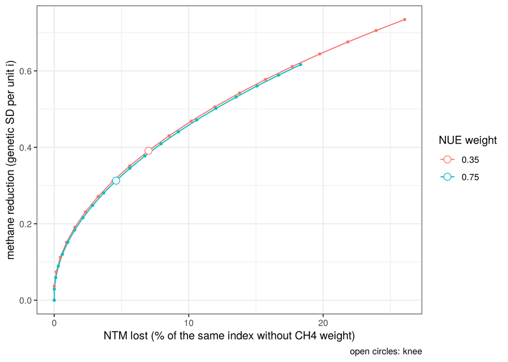

```r
ggplot2::ggplot(sw, ggplot2::aes(ntm_lost_pct, red, colour = factor(nue))) + ggplot2::geom_path() + ggplot2::geom_point(size = 0.8) +
  ggplot2::geom_point(data = knee, ggplot2::aes(ntm_lost_pct, reduction), size = 3, shape = 21, fill = "white") + ggplot2::theme_bw() +
  ggplot2::labs(x = "NTM lost (% of the same index without CH4 weight)", y = "methane reduction (genetic SD per unit i)",
                colour = "NUE weight", caption = "open circles: knee")
```

```r
ch4_name <- sprintf("GS_NTM_NUE%02d_CH4", round(100 * ch4_pick$nue))
idx_def <- data.table(index = c("GS_NTM", "GS_NTM_NUE35", "GS_NTM_NUE75", "GS_NTM_NUE35_MUN", ch4_name),
                      nue = c(0, 0.35, 0.75, 0.35, ch4_pick$nue), mun = c(0, 0, 0, -0.35, 0),
                      ch4 = c(0, 0, 0, 0, ch4_pick$ch4_weight))
kable(idx_def, caption = "Selection indices on top of NTM (weights per genetic SD)")
```

Selection indices on top of NTM (weights per genetic SD)

| index | nue | mun | ch4 |
| --- | --- | --- | --- |
| GS_NTM | 0.00 | 0.00 | 0.0 |
| GS_NTM_NUE35 | 0.35 | 0.00 | 0.0 |
| GS_NTM_NUE75 | 0.75 | 0.00 | 0.0 |
| GS_NTM_NUE35_MUN | 0.35 | -0.35 | 0.0 |
| GS_NTM_NUE75_CH4 | 0.75 | 0.00 | -0.5 |

```r
index_weights <- rbindlist(lapply(c("HOL", "RDC", "JER"), function(b) rbindlist(lapply(seq_len(nrow(idx_def)), function(i)
  data.table(index = idx_def$index[i], breed = b, trait = traits,
             weight = build_w(b, idx_def$nue[i], idx_def$mun[i], idx_def$ch4[i]))))))
kable(dcast(index_weights[weight != 0 | trait == "NUE"], trait ~ index + breed, value.var = "weight"), digits = 3,
      caption = "Index weights per genetic SD used by file 04 (0 for all other traits)")
```

Index weights per genetic SD used by file 04 (0 for all other traits)

| trait | GS_NTM_HOL | GS_NTM_JER | GS_NTM_RDC | GS_NTM_NUE35_HOL | GS_NTM_NUE35_JER | GS_NTM_NUE35_RDC | GS_NTM_NUE35_MUN_HOL | GS_NTM_NUE35_MUN_JER | GS_NTM_NUE35_MUN_RDC | GS_NTM_NUE75_HOL | GS_NTM_NUE75_JER | GS_NTM_NUE75_RDC | GS_NTM_NUE75_CH4_HOL | GS_NTM_NUE75_CH4_JER | GS_NTM_NUE75_CH4_RDC |
| --- | --- | --- | --- | --- | --- | --- | --- | --- | --- | --- | --- | --- | --- | --- | --- |
| CH4 | NA | NA | NA | NA | NA | NA | NA | NA | NA | NA | NA | NA | -0.500 | -0.500 | -0.500 |
| FY | 0.292 | 0.270 | 0.311 | 0.292 | 0.270 | 0.311 | 0.292 | 0.270 | 0.311 | 0.292 | 0.270 | 0.311 | 0.292 | 0.270 | 0.311 |
| ICF | -0.360 | -0.260 | -0.360 | -0.360 | -0.260 | -0.360 | -0.360 | -0.260 | -0.360 | -0.360 | -0.260 | -0.360 | -0.360 | -0.260 | -0.360 |
| LONG | 0.060 | 0.090 | 0.060 | 0.060 | 0.090 | 0.060 | 0.060 | 0.090 | 0.060 | 0.060 | 0.090 | 0.060 | 0.060 | 0.090 | 0.060 |
| MUN | NA | NA | NA | NA | NA | NA | -0.350 | -0.350 | -0.350 | NA | NA | NA | NA | NA | NA |
| MY | -0.174 | -0.161 | -0.162 | -0.174 | -0.161 | -0.162 | -0.174 | -0.161 | -0.162 | -0.174 | -0.161 | -0.162 | -0.174 | -0.161 | -0.162 |
| NUE | 0.000 | 0.000 | 0.000 | 0.350 | 0.350 | 0.350 | 0.350 | 0.350 | 0.350 | 0.750 | 0.750 | 0.750 | 0.750 | 0.750 | 0.750 |
| PY | 0.803 | 0.741 | 0.901 | 0.803 | 0.741 | 0.901 | 0.803 | 0.741 | 0.901 | 0.803 | 0.741 | 0.901 | 0.803 | 0.741 | 0.901 |
| SCS | -0.300 | -0.440 | -0.260 | -0.300 | -0.440 | -0.260 | -0.300 | -0.440 | -0.260 | -0.300 | -0.440 | -0.260 | -0.300 | -0.440 | -0.260 |
| SF | 0.350 | 0.380 | 0.350 | 0.350 | 0.380 | 0.350 | 0.350 | 0.380 | 0.350 | 0.350 | 0.380 | 0.350 | 0.350 | 0.380 | 0.350 |

**Expected trade-off (selection-index theory).** For an index on true breeding values, the response of trait *j* per unit of selection intensity is (G w)<sub>j</sub> / sqrt(w’ G w), with G the genetic correlation matrix above. The NTM value of a response is 10 x sum of NTM weight x response (index units), converted to EUR per cow-year with Fikse & Kargo (2020). This ignores accuracy and the non-simulated sub-indices; file 04 gives the simulated values.

```r
frontier <- rbindlist(lapply(c("HOL", "RDC", "JER"), function(b) {
  w0 <- build_w(b); V0 <- 10 * sum(w0 * resp(w0))
  rbindlist(lapply(seq(0, 1, by = 0.05), function(l) {
    r <- resp(build_w(b, nue = l)); V <- 10 * sum(w0 * r)
    data.table(breed = b, nue_weight = l, NUE = r["NUE"], MUN = r["MUN"], CH4 = r["CH4"], MY = r["MY"],
               PY = r["PY"], NTM_units = V, NTM_pct_of_max = 100 * V / V0,
               EUR_loss_per_cow_yr = (V0 - V) * eur_per_ntm[[b]])
  }))
}))
kable(frontier[nue_weight %in% c(0, 0.35, 0.75)], digits = 3,
      caption = "Response per unit selection intensity (genetic SD) and NTM value retained, at the three simulated NUE weights")
```

| breed | nue_weight | NUE | MUN | CH4 | MY | PY | NTM_units | NTM_pct_of_max | EUR_loss_per_cow_yr |
| --- | --- | --- | --- | --- | --- | --- | --- | --- | --- |
| HOL | 0.00 | 0.551 | 0.222 | 0.247 | 0.568 | 0.790 | 10.383 | 100.000 | 0.000 |
| HOL | 0.75 | 0.836 | 0.091 | 0.280 | 0.623 | 0.884 | 9.534 | 91.825 | 8.402 |
| RDC | 0.00 | 0.586 | 0.208 | 0.279 | 0.620 | 0.838 | 11.334 | 100.000 | 0.000 |
| RDC | 0.75 | 0.839 | 0.088 | 0.298 | 0.652 | 0.906 | 10.572 | 93.276 | 7.011 |
| JER | 0.00 | 0.524 | 0.230 | 0.218 | 0.524 | 0.745 | 10.350 | 100.000 | 0.000 |
| JER | 0.75 | 0.826 | 0.097 | 0.263 | 0.599 | 0.862 | 9.448 | 91.285 | 7.216 |

[figure not shown]

```r
ggplot2::ggplot(frontier, ggplot2::aes(NTM_pct_of_max, NUE, colour = breed)) + ggplot2::geom_path() +
  ggplot2::geom_point(data = frontier[nue_weight %in% c(0, 0.35, 0.75)], size = 2.5) + ggplot2::theme_bw() +
  ggplot2::labs(x = "NTM response, % of NTM-only index", y = "NUE response (genetic SD per unit i)",
                caption = "points: NUE weight 0, 0.35, 0.75")
```

# 7 Sensitivity analysis: every NUE correlation scaled

All NUE correlations are uncertain (one grazing Irish study plus implied values; no Nordic estimate exists). To show how much the conclusions rest on them, the burn-in and the GS_NTM and GS_NTM_NUE35 programmes are also run with **every NUE correlation multiplied by s = 0 and s = 0.5** (s = 1 is the main run). With D = diag(1, …, s, …, 1) at the NUE position, the scaled matrix is R<sub>s</sub> = D R D + (1 - s<sup>2</sup>) e e’, where e is the NUE unit vector. Both terms are positive semi-definite and the first is positive definite, so R<sub>s</sub> is a valid correlation matrix for every s in [0, 1] without any further bending, and all non-NUE correlations are unchanged.

```r
nue_scale <- function(R, s) {
  D <- diag(ifelse(rownames(R) == "NUE", s, 1)); Rs <- D %*% R %*% D
  Rs[cbind(which(rownames(R) == "NUE"), which(rownames(R) == "NUE"))] <- 1
  dimnames(Rs) <- dimnames(R); Rs
}
sens <- rbindlist(lapply(c(0, 0.5, 1), function(sc) {
  Rs <- nue_scale(RG, sc); stopifnot(min(eigen(Rs, only.values = TRUE)$values) > 0)
  if (sc < 1) saveRDS(Rs, sprintf("params/RG_matrix_NUEx%s.rds", sub("\\.", "", format(sc))))
  rbindlist(lapply(c("HOL", "RDC", "JER"), function(b) {
    w0 <- build_w(b); w35 <- build_w(b, nue = 0.35)
    r0 <- drop(Rs %*% w0) / sqrt(drop(t(w0) %*% Rs %*% w0)); r35 <- drop(Rs %*% w35) / sqrt(drop(t(w35) %*% Rs %*% w35))
    data.table(nue_scale = sc, breed = b, NUE_GS_NTM = r0["NUE"], NUE_GS_NTM_NUE35 = r35["NUE"],
               NTM_kept_pct = 100 * sum(w0 * r35) / sum(w0 * r0))
  }))
}))
kable(sens, digits = 3, caption = "Selection-index theory under the three NUE scalings (response per unit i, genetic SD)")
```

Selection-index theory under the three NUE scalings (response per unit i, genetic SD)

| nue_scale | breed | NUE_GS_NTM | NUE_GS_NTM_NUE35 | NTM_kept_pct |
| --- | --- | --- | --- | --- |
| 0.0 | HOL | 0.000 | 0.319 | 94.761 |
| 0.0 | RDC | 0.000 | 0.295 | 95.548 |
| 0.0 | JER | 0.000 | 0.320 | 94.730 |
| 0.5 | HOL | 0.275 | 0.537 | 95.874 |
| 0.5 | RDC | 0.293 | 0.533 | 96.524 |
| 0.5 | JER | 0.262 | 0.528 | 95.788 |
| 1.0 | HOL | 0.551 | 0.729 | 97.299 |
| 1.0 | RDC | 0.586 | 0.741 | 97.827 |
| 1.0 | JER | 0.524 | 0.711 | 97.135 |

```r
fwrite(sens, "params/nue_sensitivity_theory.csv")
```

**Saved Feed heritability sensitivity.** Lidauer et al. (NAV workshop, Copenhagen, 20 Jan 2026; Finnish Nordic Red, 537 primiparous cows) estimated h<sup>2</sup> = 0.08 for the NAV Saved Feed index itself, against 0.23 for ReFI used in the main run. The main run keeps 0.23; a sensitivity set with SF h<sup>2</sup> = 0.08 in all breeds (everything else unchanged) is written for file 01.

```r
h2_sf <- copy(h2)[code == "SF", `:=`(HOL = 0.08, RDC = 0.08, JER = 0.08, range_low = NA_real_, range_high = NA_real_,
  status = "SENSITIVITY (NAV Saved Feed index h2; Finnish Nordic Red, 537 cows; no SE given)",
  source = "Lidauer et al., NAV workshop Copenhagen 20 Jan 2026 (slides)")]
fwrite(h2_sf, "params/h2_SFh008.csv")
```

# 8 Save parameters for downstream files

```r
dir.create("params", showWarnings = FALSE)
fwrite(index_weights, "params/index_weights.csv")
fwrite(ntm_w, "params/ntm_weights_source.csv")
fwrite(frontier, "params/ntm_nue_frontier.csv")
fwrite(sw, "params/ch4_weight_sweep.csv"); fwrite(idx_def, "params/index_definitions.csv")
fwrite(h2, "params/h2.csv")
fwrite(rg_src, "params/rg_sourced.csv")
saveRDS(RG, "params/RG_matrix.rds")
fwrite(split, "params/breed_country_split.csv")
fwrite(farms, "params/herds.csv")
fwrite(gxe_scenarios, "params/gxe_scenarios.csv")
list.files("params")
```

```
##  [1] "RG_candidates_QR_MA.rds"       "RG_matrix.rds"
##  [3] "RG_matrix_NUEx0.rds"           "RG_matrix_NUEx05.rds"
##  [5] "breed_country_split.csv"       "ch4_weight_sweep.csv"
##  [7] "gxe_scenarios.csv"             "h2.csv"
##  [9] "h2_SFh008.csv"                 "herds.csv"
## [11] "index_definitions.csv"         "index_weights.csv"
## [13] "ntm_nue_frontier.csv"          "ntm_weights_source.csv"
## [15] "nue_sensitivity_theory.csv"    "rg_candidates_2026-11-03.csv"
## [17] "rg_candidates_2026-11-04.csv"  "rg_candidates_7nov.csv"
## [19] "rg_sourced.csv"                "rg_update_bending_check.csv"
## [21] "rg_update_index_theory.csv"    "unsourced_pairs.csv"
## [23] "update_check_index_theory.csv"
```

# 9 Open items blocking full verification

[output not shown]